# EXPLORATORY ANALYSIS

#### OLS Regression FAA (F4-F3) ~ BIS/BAS-scores + UPPS-scores + Gender + Age

```r
summary(full.modelF4F3 <- lm(FAA.F4F3 ~ BAS.Drive+BAS.Fun+BAS.Reward+BIS+UPPS.Urgency+UPPS.Lack.Premed+UPPS.Lack.Persev+UPPS.Sens.Seek+Gender+Age, data = dataF4F3))
```

```
Call:
lm(formula = FAA.F4F3 ~ BAS.Drive + BAS.Fun + BAS.Reward + BIS +
    UPPS.Urgency + UPPS.Lack.Premed + UPPS.Lack.Persev + UPPS.Sens.Seek +
    Gender + Age, data = dataF4F3)

Residuals:
     Min       1Q   Median       3Q      Max
-1.62710 -0.23517 -0.00639  0.20788  1.42271

Coefficients:
                   Estimate Std. Error t value Pr(>|t|)
(Intercept)       0.2442195  0.4347793   0.562   0.5749
BAS.Drive         0.0054568  0.0194701   0.280   0.7796
BAS.Fun          -0.0083993  0.0199004  -0.422   0.6734
BAS.Reward       -0.0266824  0.0182476  -1.462   0.1452
BIS              -0.0045432  0.0105997  -0.429   0.6687
UPPS.Urgency      0.0089813  0.0066469   1.351   0.1782
UPPS.Lack.Premed  0.0002319  0.0078806   0.029   0.9766
UPPS.Lack.Persev -0.0003051  0.0077612  -0.039   0.9687
UPPS.Sens.Seek    0.0020919  0.0054138   0.386   0.6996
Gender1           0.1335841  0.0667410   2.002   0.0467 *
Age1              0.1719409  0.0742098   2.317   0.0215 *
---
Signif. codes:  0 ‘***’ 0.001 ‘**’ 0.01 ‘*’ 0.05 ‘.’ 0.1 ‘ ’ 1

Residual standard error: 0.4085 on 200 degrees of freedom
Multiple R-squared:  0.07258,   Adjusted R-squared:  0.02621
F-statistic: 1.565 on 10 and 200 DF,  p-value: 0.1192
```

## **Checking of Assumptions and Diagnostics**

### 1 Unusual Observations

Unusual observations may disproportionately influence the outcomes of the models. Multiple linear regression is not very robust against these types of observations.

In the absence of outliers and with the fulfillment of the assumptions of zero mean, constant variance and uncorrelated errors the OLS provides the Best Linear Unbiased Estimators (BLUE) of the regression parameters. But any anomalous point can disproportionately pull the line and distort the predictions. Detection of outlying observations is a very essential part of good regression analysis.

An influential observation is one which either individually or together with several other observations, has a demonstrably larger impact on the calculated values of various estimates (coefficient, standard errors, t-values, etc.) than to the case for most of the other observation (Belsley et al., 1980).

#### 1.1 Outliers

An outlier is an observation with a large residual

**MODEL 2 (F4-F3)**

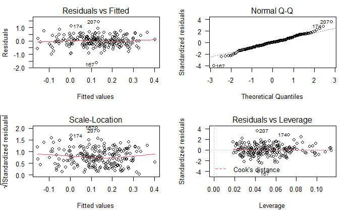

|  | rstudent | unadjusted p-value | Bonferroni p |
| --- | --- | --- | --- |
| 167 | -4.241908 | 3.3941e-05 | 0.0071615 |

From the plots, observations 167, 174, 207 are possibly problematic. Observation 167 is identified as an outlier in the outlier test.

#### 1.2 Influential Observations

Cook’s Distance. Cut-off points of *4/n*. A measure that combines the information of leverage and the residual of the observation.

|  | ID | BAS.Drive | BAS.Fun | BAS.Reward | BIS | FAA.F4F3 | UPPS.Urgency | UPPS.Lack.Premed | UPPS.Lack.Persev | UPPS.Sens.Seek | Gender | Age | d2 | r2 |
| --- | --- | --- | --- | --- | --- | --- | --- | --- | --- | --- | --- | --- | --- | --- |
| 46 | sub-010059 | 11 | 14 | 17 | 18 | -1.0748563 | 22 | 26 | 18 | 30 | 0 | 0 | 0.02714848 | -2.474565 |
| 69 | sub-010083 | 12 | 15 | 20 | 26 | 0.9721646 | 37 | 29 | 17 | 33 | 1 | 1 | 0.02665121 | 1.865534 |
| 77 | sub-010091 | 15 | 12 | 17 | 15 | -0.8367833 | 17 | 26 | 19 | 31 | 0 | 0 | 0.02104294 | -1.913631 |
| 123 | sub-010220 | 10 | 12 | 15 | 17 | 1.0790366 | 19 | 18 | 32 | 36 | 0 | 1 | 0.04936715 | 2.421351 |
| 134 | sub-010234 | 14 | 12 | 19 | 21 | -0.9540718 | 24 | 17 | 13 | 17 | 1 | 0 | 0.02423547 | -2.394692 |
| 155 | sub-010258 | 15 | 15 | 17 | 17 | -0.8036450 | 26 | 18 | 14 | 25 | 1 | 0 | 0.02900048 | -2.251857 |
| 167 | sub-010271 | 16 | 13 | 18 | 19 | -1.5031325 | 24 | 24 | 21 | 39 | 0 | 1 | 0.06816979 | -4.072420 |
| 174 | sub-010278 | 16 | 15 | 19 | 18 | 1.1188101 | 34 | 25 | 13 | 39 | 0 | 0 | 0.05711712 | 2.830224 |
| 177 | sub-010282 | 15 | 14 | 16 | 19 | -0.9080702 | 29 | 20 | 20 | 25 | 0 | 0 | 0.03201128 | -2.311666 |
| 207 | sub-010316 | 14 | 10 | 19 | 20 | 1.5575862 | 27 | 20 | 15 | 39 | 0 | 1 | 0.05068654 | 3.558839 |

### 2 Residuals are Normaly Distributed

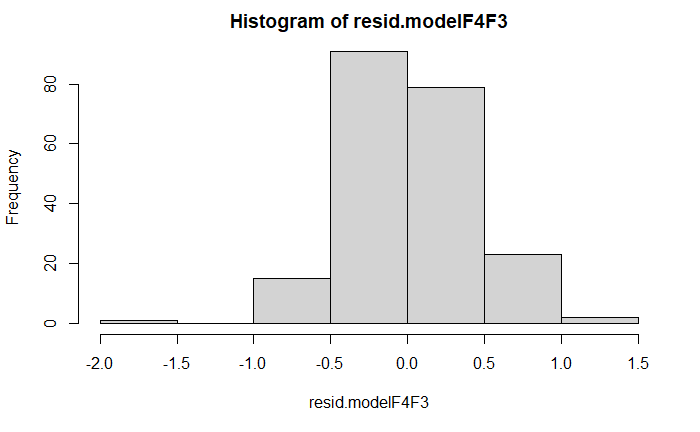

```r
shapiro.test(resid.modelF4F3) # NOT NORMAL - INDICATES ASSUMPTION DOES NOT HOLD
```

```
    Shapiro-Wilk normality test

data:  resid.modelF4F3
W = 0.9838, p-value = 0.01602
```

The significant Shapiro-Wilks test indicates that the assumption of multivariate normality does not hold

### 3 Homoscedasticity

This assumption states that the variance of error terms are similar across the values of the independent variables. A plot of standardized residuals versus predicted values can show whether points are equally distributed across all values of the independent variables.

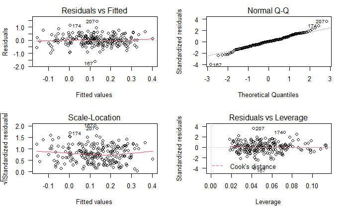

The plots of interest here are at the top-left and bottom-left. The top-left is the chart of residuals vs fitted values, while in the bottom-left one, it is standardised residuals on Y axis. If there is absolutely no heteroscedastity, there should be a completely random, equal distribution of points throughout the range of X axis and a flat red line. As previously seen, observations 167, 174, 207 are possibly problematic, but over all it looks good, there is are no clear patterns in the plots. The Breush-Pagan test and the NCV test can be used to test for heteroscedasticity.

### 4 Linear Relationship Between the Dependent Variable (FAA) and the Independent Variables

#### 4.1 Matrices of Pearson and Spearman correlations

##### 4.1.1 Pearson

```r
round(corrplot[["r"]], digits = 3)
```

```
                 BAS.Drive BAS.Fun BAS.Reward    BIS FAA.F2F1 FAA.F4F3 FAA.F6F5 FAA.F8F7 UPPS.Urgency
BAS.Drive            1.000   0.287      0.562 -0.118   -0.040   -0.058   -0.057   -0.082       -0.023
BAS.Fun              0.287   1.000      0.292 -0.067    0.124    0.005    0.049    0.102        0.177
BAS.Reward           0.562   0.292      1.000  0.084    0.000   -0.088   -0.079    0.017        0.086
BIS                 -0.118  -0.067      0.084  1.000   -0.057    0.048    0.081    0.112        0.335
FAA.F2F1            -0.040   0.124      0.000 -0.057    1.000    0.484    0.052    0.223        0.073
FAA.F4F3            -0.058   0.005     -0.088  0.048    0.484    1.000    0.669    0.292        0.118
FAA.F6F5            -0.057   0.049     -0.079  0.081    0.052    0.669    1.000    0.500        0.053
FAA.F8F7            -0.082   0.102      0.017  0.112    0.223    0.292    0.500    1.000        0.043
UPPS.Urgency        -0.023   0.177      0.086  0.335    0.073    0.118    0.053    0.043        1.000
UPPS.Lack.Premed    -0.161   0.156     -0.082 -0.121   -0.016    0.061    0.059    0.035        0.121
UPPS.Lack.Persev    -0.502   0.085     -0.311  0.139    0.058    0.048    0.011    0.080        0.162
UPPS.Sens.Seek       0.189   0.352      0.111 -0.126    0.078    0.061    0.017    0.066        0.037
                 UPPS.Lack.Premed UPPS.Lack.Persev UPPS.Sens.Seek
BAS.Drive                  -0.161           -0.502          0.189
BAS.Fun                     0.156            0.085          0.352
BAS.Reward                 -0.082           -0.311          0.111
BIS                        -0.121            0.139         -0.126
FAA.F2F1                   -0.016            0.058          0.078
FAA.F4F3                    0.061            0.048          0.061
FAA.F6F5                    0.059            0.011          0.017
FAA.F8F7                    0.035            0.080          0.066
UPPS.Urgency                0.121            0.162          0.037
UPPS.Lack.Premed            1.000            0.236          0.245
UPPS.Lack.Persev            0.236            1.000          0.039
UPPS.Sens.Seek              0.245            0.039          1.000
```

##### 4.1.2 Spearman

```r
round(corrplot2[["r"]], digits = 3)
```

```
                 BAS.Drive BAS.Fun BAS.Reward    BIS FAA.F2F1 FAA.F4F3 FAA.F6F5 FAA.F8F7 UPPS.Urgency
BAS.Drive            1.000   0.277      0.567 -0.095   -0.039   -0.033   -0.079   -0.086       -0.044
BAS.Fun              0.277   1.000      0.282 -0.045    0.120    0.025    0.029    0.076        0.174
BAS.Reward           0.567   0.282      1.000  0.085   -0.045   -0.076   -0.075   -0.025        0.087
BIS                 -0.095  -0.045      0.085  1.000   -0.082    0.026    0.056    0.076        0.370
FAA.F2F1            -0.039   0.120     -0.045 -0.082    1.000    0.518    0.111    0.230        0.018
FAA.F4F3            -0.033   0.025     -0.076  0.026    0.518    1.000    0.671    0.244        0.066
FAA.F6F5            -0.079   0.029     -0.075  0.056    0.111    0.671    1.000    0.465        0.023
FAA.F8F7            -0.086   0.076     -0.025  0.076    0.230    0.244    0.465    1.000        0.029
UPPS.Urgency        -0.044   0.174      0.087  0.370    0.018    0.066    0.023    0.029        1.000
UPPS.Lack.Premed    -0.160   0.159     -0.060 -0.112   -0.057    0.081    0.053    0.036        0.083
UPPS.Lack.Persev    -0.495   0.098     -0.300  0.125    0.073    0.040    0.017    0.073        0.199
UPPS.Sens.Seek       0.202   0.354      0.112 -0.127    0.094    0.034    0.005    0.060        0.016
                 UPPS.Lack.Premed UPPS.Lack.Persev UPPS.Sens.Seek
BAS.Drive                  -0.160           -0.495          0.202
BAS.Fun                     0.159            0.098          0.354
BAS.Reward                 -0.060           -0.300          0.112
BIS                        -0.112            0.125         -0.127
FAA.F2F1                   -0.057            0.073          0.094
FAA.F4F3                    0.081            0.040          0.034
FAA.F6F5                    0.053            0.017          0.005
FAA.F8F7                    0.036            0.073          0.060
UPPS.Urgency                0.083            0.199          0.016
UPPS.Lack.Premed            1.000            0.227          0.261
UPPS.Lack.Persev            0.227            1.000          0.068
UPPS.Sens.Seek              0.261            0.068          1.000
```

### 5 No Multicollinearity

The correlation matrices shows low correlations between the independent variables. Variance Inflation Factor (VIF) test shows the same, no collinearity.

```r
# VARIANCE INFLATION FACTOR (VIF) - LOOKS GOOD
car::vif(full.modelF4F3)
```

```
       BAS.Drive          BAS.Fun       BAS.Reward              BIS     UPPS.Urgency UPPS.Lack.Premed
        2.042001         1.401957         1.604372         1.352165         1.222552         1.231561
UPPS.Lack.Persev   UPPS.Sens.Seek           Gender              Age
        1.677814         1.808041         1.305480         1.554885
```

There are a couple of outliers and some influential observations. Several variables (not tested here) are non-normal. I am considering robust regression.

### References:

Belsley, D.A., Kuh. E and Welsch, R.E., Regression Diagnostics: Identifying Influential Data and Sources of Collinearity, Wiley, New York, (1980).

### Useful Links:

[Assumptions of Multiple Linear Regression](https://www.statisticssolutions.com/assumptions-of-multiple-linear-regression/)  
[Identifying Unusual Observations](https://towardsdatascience.com/how-to-detect-unusual-observations-on-your-regression-model-with-r-de0eaa38bc5b)  
[Robust Regression](https://stats.idre.ucla.edu/r/dae/robust-regression/)  
[Properites of OLF Estimates](https://www.albert.io/blog/ultimate-properties-of-ols-estimators-guide/)